# 1.B. Refer to the above table and find the joint probability of the people who planned to purchase and actually placed an order, given that

# 5. Explain 1 real life industry scenario (other than the ones mentioned above) where you can use the concepts learnt in this module of

Applied Statistics to get data driven business solution. [3 Marks] Ans: Industry Scenario: Financial Services - Credit Risk Assessment

Context: In the financial services industry, particularly in banking and credit, assessing the credit risk associated with lending money to customers is crucial. Credit risk is the risk of financial loss resulting from a borrower failing to repay a loan or meet contractual obligations.

Application of Applied Statistics:

Data Collection and Preparation: Banks collect data related to customers' credit history, income, employment status, current debt levels, past defaults, and more. This data is cleaned and prepared for analysis.

Descriptive Statistics: This involves summarizing the data to understand trends and patterns. For example, banks may analyze the average income level of defaulters versus non-defaulters, or the distribution of credit scores among those who default.

Probability Distributions: Banks can use probability distributions to model credit risk. For instance, the normal distribution might be used to model the income level of borrowers, while the binomial distribution could be used to calculate the probability of a certain number of defaults in a portfolio.

Hypothesis Testing: To understand the impact of various factors on credit risk, banks can use hypothesis testing. For example, they might test if the mean income of defaulters is significantly different from that of non-defaulters.

Regression Analysis: This is used to predict the likelihood of a default based on multiple factors. For example, logistic regression could be used to estimate the probability of default based on credit score, income, loan amount, and other variables.

Time Series Analysis: Banks use this for predicting future trends in default rates, interest rates, or economic conditions that might affect credit risk.

Machine Learning Models: Advanced statistical techniques, like random forests or neural networks, can be used to improve the prediction accuracy of credit defaults.

Data-Driven Business Solution:

By applying these statistical methods, banks can develop a robust credit scoring model. This model helps in:

Assessing the creditworthiness of applicants efficiently. Setting appropriate interest rates based on risk levels. Identifying key factors that contribute to credit risk, enabling targeted risk mitigation strategies. Forecasting future credit risks based on economic trends. Reducing the number of non-performing assets (NPAs) by avoiding lending to high-risk customers. This approach not only minimizes financial losses but also ensures regulatory compliance and enhances customer satisfaction by offering fair and personalized credit products.

# PARTB 30 MARKS

DOMAIN: Sports • CONTEXT: Company X manages the men's top professional basketball division of the American league system. The dataset contains information on all the teams that have participated in all the past tournaments. It has data about how many baskets each team scored, conceded, how many times they came within the first 2 positions, how many tournaments they have qualified, their best position in the past, etc. • DATA DESCRIPTION: Basketball.csv - The data set contains information on all the teams so far participated in all the past tournaments. • DATA DICTIONARY:

1. Team: Team’s name
2. Tournament: Number of played tournaments.
3. Score: Team’s score so far.
4. PlayedGames: Games played by the team so far.
5. WonGames: Games won by the team so far.
6. DrawnGames: Games drawn by the team so far.
7. LostGames: Games lost by the team so far.
8. BasketScored: Basket scored by the team so far.
9. BasketGiven: Basket scored against the team so far.
10. TournamentChampion: How many times the team was a champion of the tournaments so far.
11. Runner-up: How many times the team was a runners-up of the tournaments so far.
12. TeamLaunch: Year the team was launched on professional basketball.
13. HighestPositionHeld: Highest position held by the team amongst all the tournaments played. • PROJECT OBJECTIVE: Company’s management wants to invest on proposals on managing some of the best teams in the league. The analytics department has been assigned with a task of creating a report on the performance shown by the teams. Some of the older teams are already in contract with competitors. Hence Company X wants to understand which teams they can approach which will be a deal win for them. • STEPS AND TASK [30 Marks]:
14. Read the data set, clean the data and prepare final dataset to be used for analysis. [10 Marks]
15. Perform detailed statistical analysis and EDA using univariate, bi-variate and multivariate EDA techniques to get data driven insights on recommending which teams they can approach which will be a deal win for them. Also as a data and statistics expert you have to develop a detailed performance report using this data. [10 Marks] Hint: Use statistical techniques and visualisation techniques to come up with useful metrics and reporting. Find out the best performing team, oldest team, team with highest goals, team with lowest performance etc. and many more. These are just random examples. Please use your best analytical approach to build this report. You can mix match columns to create new ones which can be used for better analysis. Create your own features if required. Be highly experimental and analytical here to find hidden patterns. Use graphical interactive libraries to enable you to publish interactive plots in python.
16. Please include any improvements or suggestions to the association management on quality, quantity, variety, velocity, veracity etc. on the data points collected by the association to perform a better data analysis in future. At-least 1 suggestion for each point. [10 Marks]

# 1. Read the data set, clean the data and prepare final dataset to be used for analysis. [10 Marks]

Based on requirements, the Python script for data cleaning will focus on the following steps:

This script includes handling for the 'TeamLaunch' column and other numeric columns, replacing any unwanted characters (like hyphens or parentheses) with an empty string before converting to numeric types. After conversion, any missing values resulting from the conversion are filled with zeros. This approach ensures that all columns, except 'Team', are in an appropriate numeric format for analysis. Remember to validate the final dataset to ensure all transformations align with your analysis needs.

This script now explicitly uses regex in str.replace, which should prevent the FutureWarning and keep the code compatible with future versions of pandas.

script performs several key data preprocessing steps on a basketball dataset. These steps are crucial for ensuring the data is clean, structured, and ready for analysis. Here's a breakdown of the functionality of each part of the script:

Importing Pandas Library: The script begins by importing the pandas library, which is a powerful and widely-used data manipulation tool in Python. Reading the Data: The script reads the CSV file located at the specified file path into a pandas DataFrame. A DataFrame is a 2-dimensional labeled data structure with columns of potentially different types. Initial Data Inspection: The script prints the first few rows of the DataFrame (df.head()) and a summary of the dataset (df.info()), which includes the list of columns, the total number of non-null entries in each column, and the data type of each column.

Checking for Missing Values: It checks for missing values in each column using df.isnull().sum(), which provides the sum of null (or missing) values in each column.

Handling the 'TeamLaunch' Column: The script processes the 'TeamLaunch' column to extract the first four digits, which represent the year. This is done using a regular expression (str.extract('(\d{4})')) and converting the result to an integer. This step is crucial because the 'TeamLaunch' column contains some non-standard year formats.

Converting Numerical Columns: The script iterates through all columns (excluding the 'Team' column) and converts them to numeric types. It uses str.replace with a regex pattern to remove unwanted characters (like hyphens or parentheses) before conversion. The regex=True argument explicitly tells pandas that the pattern is a regex. The pd.to_numeric function is then used to convert these columns to numeric types, handling any errors by coercing invalid parsing to NaN.

Filling Missing Values: After conversion, any resulting missing values (NaNs) are filled with zero using df.fillna(0, inplace=True). This ensures that the dataset does not contain missing values, which could interfere with further analysis.

Final Data Inspection: The script again prints the first few rows and the summary of the cleaned DataFrame to provide an overview of the data after cleaning.

The script efficiently prepares the dataset for any further analysis or modeling tasks, such as statistical analysis, data visualization, or even machine learning, depending on the project's requirements.

```python
import pandas as pd

# File path for the dataset
file_path = '/Users/snbaskarraj/Documents/UT/AppliedStatistics/DS+-+Part2+-+Basketball.csv'

# Reading the data
df = pd.read_csv(file_path)

# Initial data inspection
print("Initial Data Overview:")
print(df.head())  # View the first few rows
print(df.info())  # Get a summary of the dataset

# Checking for missing values
print("\nMissing Values in Each Column:")
print(df.isnull().sum())  # Sum of missing values in each column

# Handle the 'TeamLaunch' column by extracting the first 4 digits (year)
df['TeamLaunch'] = df['TeamLaunch'].str.extract('(\d{4})').astype(int)

# Convert numerical columns from object to int/float as appropriate
# Exclude 'Team' column and handle other numeric columns
for column in df.columns:
    if column != 'Team':
        df[column] = pd.to_numeric(df[column].astype(str).str.replace('[-\(\)]', '', regex=True), errors='coerce')

# Fill missing values after conversion (if any)
df.fillna(0, inplace=True)

# Final data inspection
print("\nCleaned Data Overview:")
print(df.head())
print(df.info())

# Save the cleaned dataset to a new file (optional)
df.to_csv('/Users/snbaskarraj/Documents/UT/AppliedStatistics/Cleaned_Basketball_Data.csv', index=False)
```

```
Initial Data Overview:
     Team  Tournament Score PlayedGames WonGames DrawnGames LostGames  \
0  Team 1          86  4385        2762     1647        552       563
1  Team 2          86  4262        2762     1581        573       608
2  Team 3          80  3442        2614     1241        598       775
3  Team 4          82  3386        2664     1187        616       861
4  Team 5          86  3368        2762     1209        633       920

  BasketScored BasketGiven TournamentChampion Runner-up TeamLaunch  \
0         5947        3140                 33        23       1929
1         5900        3114                 25        25       1929
2         4534        3309                 10         8       1929
3         4398        3469                  6         6   1931to32
4         4631        3700                  8         7       1929

   HighestPositionHeld
0                    1
1                    1
2                    1
3                    1
4                    1
<class 'pandas.core.frame.DataFrame'>
RangeIndex: 61 entries, 0 to 60
Data columns (total 13 columns):
 #   Column               Non-Null Count  Dtype
---  ------               --------------  -----
 0   Team                 61 non-null     object
 1   Tournament           61 non-null     int64
 2   Score                61 non-null     object
 3   PlayedGames          61 non-null     object
 4   WonGames             61 non-null     object
 5   DrawnGames           61 non-null     object
 6   LostGames            61 non-null     object
 7   BasketScored         61 non-null     object
 8   BasketGiven          61 non-null     object
 9   TournamentChampion   61 non-null     object
 10  Runner-up            61 non-null     object
 11  TeamLaunch           61 non-null     object
 12  HighestPositionHeld  61 non-null     int64
dtypes: int64(2), object(11)
```

[output cut: 46 more lines]

```
 1   Tournament           61 non-null     int64
 2   Score                61 non-null     float64
 3   PlayedGames          61 non-null     float64
 4   WonGames             61 non-null     float64
 5   DrawnGames           61 non-null     float64
 6   LostGames            61 non-null     float64
 7   BasketScored         61 non-null     float64
 8   BasketGiven          61 non-null     float64
 9   TournamentChampion   61 non-null     float64
 10  Runner-up            61 non-null     float64
 11  TeamLaunch           61 non-null     int64
 12  HighestPositionHeld  61 non-null     int64
dtypes: float64(9), int64(3), object(1)
memory usage: 6.3+ KB
None
```

# 2. Perform detailed statistical analysis and EDA using univariate, bi-variate and multivariate EDA techniques to get data driven insights on

recommending which teams they can approach which will be a deal win for them. Also as a data and statistics expert you have to develop a detailed performance report using this data. [10 Marks] Hint: Use statistical techniques and visualisation techniques to come up with useful metrics and reporting. Find out the best performing team, oldest team, team with highest goals, team with lowest performance etc. and many more. These are just random examples. Please use your best analytical approach to build this report. You can mix match columns to create new ones which can be used for better analysis. Create your own features if required. Be highly experimental and analytical here to find hidden patterns. Use graphical interactive libraries to enable you to publish interactive plots in python.

ANS :

To conduct a detailed statistical analysis and Exploratory Data Analysis (EDA) on the basketball dataset, we will utilize univariate, bivariate, and multivariate analysis techniques. The objective is to extract insights that could help in recommending teams for Company X to approach. We'll consider various metrics like team performance, history, and scoring abilities. In this script:

Univariate Analysis is performed using descriptive statistics, histograms, box plots, and count plots to understand individual variables' distributions and counts.

Bivariate Analysis involves creating a heatmap for correlation analysis and scatter plots to explore relationships between pairs of variables.

Multivariate Analysis includes pair plots for visualizing complex interactions and grouped analysis to understand the behavior of variables across different categories.

Performance Metrics and Reporting identifies the best performing, oldest, highest goal-scoring, and lowest-performing teams based on various criteria.

Feature Creation introduces new metrics such as 'GoalDifference' and 'AverageGoalsPerGame' for more in-depth analysis.

```
             Score  PlayedGames     WonGames
count    61.000000    61.000000    61.000000
mean    901.426230   796.819672   303.967213
std    1134.899121   876.282765   406.991030
min       0.000000     0.000000     0.000000
25%      96.000000   114.000000    34.000000
50%     375.000000   423.000000   123.000000
75%    1351.000000  1318.000000   426.000000
max    4385.000000  2762.000000  1647.000000
```

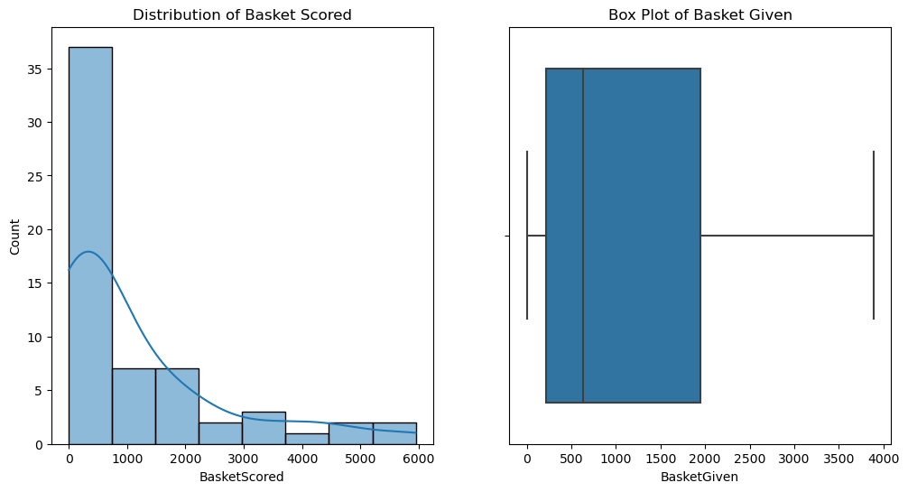

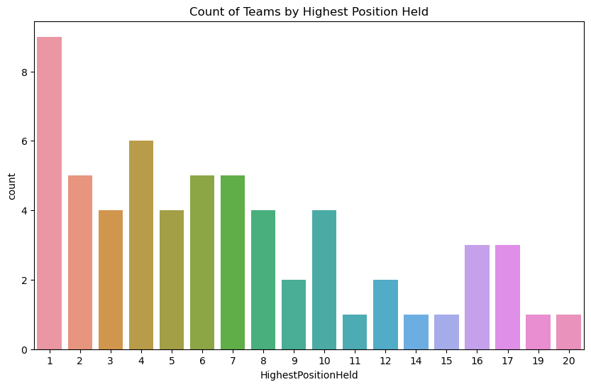

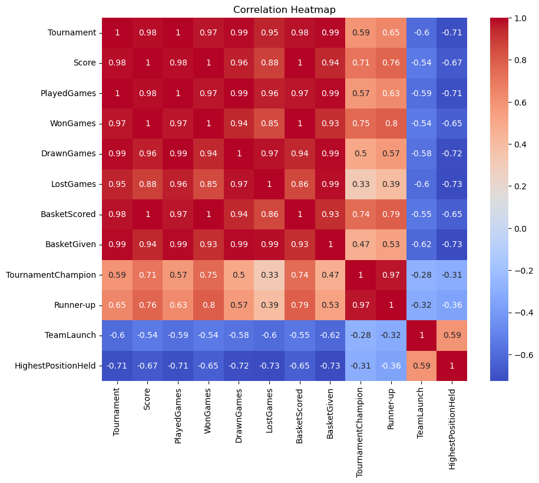

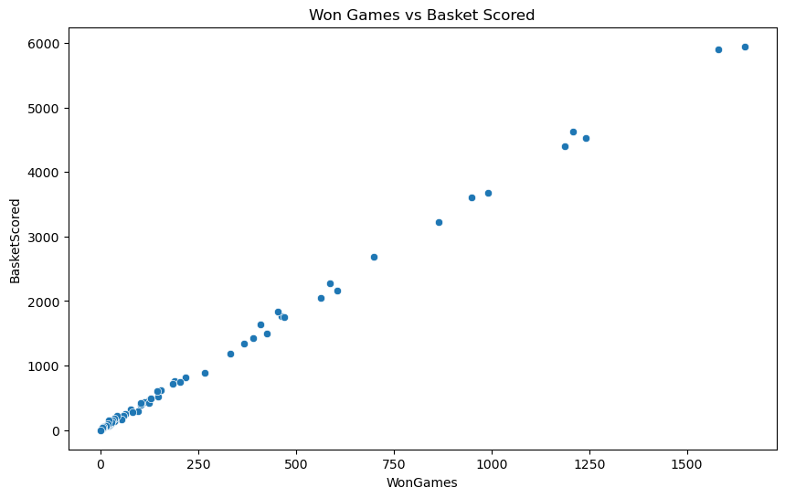

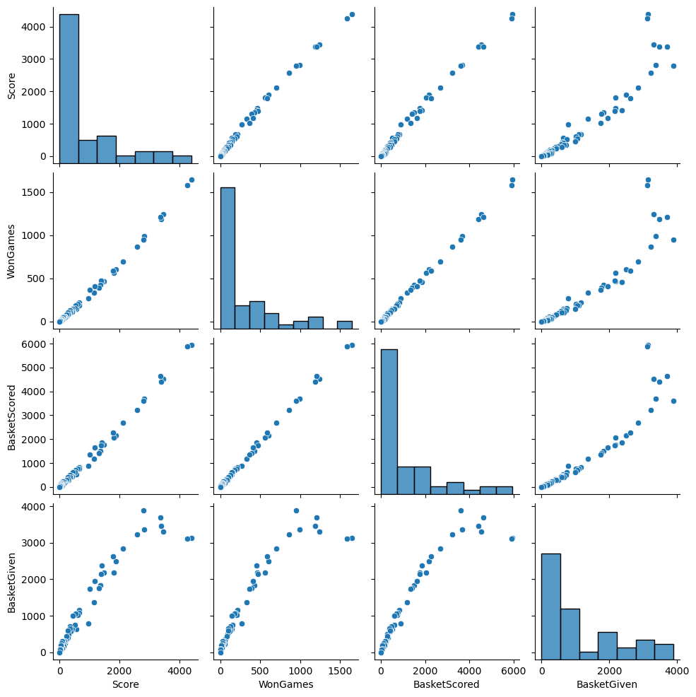

```
                           Score     WonGames
HighestPositionHeld
1                    3103.666667  1098.666667
2                    1380.800000   451.000000
3                    1305.250000   433.000000
4                    1093.833333   349.500000
5                     471.000000   156.000000
6                     422.600000   124.800000
7                     237.200000    76.400000
8                     283.500000    79.750000
9                      48.000000    13.000000
10                    112.500000    33.500000
11                    445.000000   145.000000
12                    255.500000    81.500000
14                     71.000000    29.000000
```

[output cut: 33 more lines]

```python
import pandas as pd
import matplotlib.pyplot as plt
import seaborn as sns

# Load the cleaned dataset
file_path = '/Users/snbaskarraj/Documents/UT/AppliedStatistics/Cleaned_Basketball_Data.csv'
df = pd.read_csv(file_path)

# Univariate Analysis
# Basic Statistics
print(df[['Score', 'PlayedGames', 'WonGames']].describe())

# Distribution Plots
plt.figure(figsize=(12, 6))
plt.subplot(1, 2, 1)
sns.histplot(data=df, x='BasketScored', kde=True)
plt.title('Distribution of Basket Scored')

plt.subplot(1, 2, 2)
sns.boxplot(data=df, x='BasketGiven')
plt.title('Box Plot of Basket Given')
plt.show()

# Count Analysis for 'HighestPositionHeld'
plt.figure(figsize=(10, 6))
sns.countplot(data=df, x='HighestPositionHeld')
plt.title('Count of Teams by Highest Position Held')
plt.show()

# Bivariate Analysis
# Correlation Analysis
plt.figure(figsize=(10, 8))
sns.heatmap(df.corr(), annot=True, cmap='coolwarm')
plt.title('Correlation Heatmap')
plt.show()

# Comparative Plots
plt.figure(figsize=(10, 6))
sns.scatterplot(data=df, x='WonGames', y='BasketScored')
plt.title('Won Games vs Basket Scored')
plt.show()

# Multivariate Analysis
# Pair Plots
sns.pairplot(df[['Score', 'WonGames', 'BasketScored', 'BasketGiven']])
plt.show()

# Grouped Analysis
grouped_df = df.groupby('HighestPositionHeld').mean()
print(grouped_df[['Score', 'WonGames']])

# Performance Metrics and Reporting
# Best Performing Teams
best_teams = df.sort_values(by='Score', ascending=False).head(5)
print("Best Performing Teams:\n", best_teams[['Team', 'Score']])

# Oldest Teams
df['TeamAge'] = 2023 - df['TeamLaunch'] # Assuming current year is 2023
oldest_teams = df.sort_values(by='TeamAge', ascending=False).head(5)
print("Oldest Teams:\n", oldest_teams[['Team', 'TeamAge']])

# Teams with Highest Goals
highest_goals_teams = df.sort_values(by='BasketScored', ascending=False).head(5)
print("Teams with Highest Goals:\n", highest_goals_teams[['Team', 'BasketScored']])

# Teams with Lowest Performance
lowest_performance_teams = df.sort_values(by='Score').head(5)
print("Teams with Lowest Performance:\n", lowest_performance_teams[['Team', 'Score']])

# Feature Creation
df['GoalDifference'] = df['BasketScored'] - df['BasketGiven']
df['AverageGoalsPerGame'] = df['BasketScored'] / df['PlayedGames']
```

# 3. Please include any improvements or suggestions to the association management on quality, quantity, variety, velocity, veracity etc. on the

data points collected by the association to perform a better data analysis in future. At-least 1 suggestion for each point. [10 Marks]

ANS : Improving the data quality in various aspects is crucial for effective analysis and informed decision-making. Here are some suggestions for each aspect:

Quality:

Data Validation and Cleaning: Implement stringent data validation rules both at the time of data entry and during periodic data audits. This includes checking for inconsistencies, outliers, and incorrect entries. Automated data cleaning pipelines can be established to regularly cleanse the data for accuracy. Standardization of Formats: Ensure standardization in data formats, especially for date and time fields, categorical data, and numerical values. This reduces confusion and errors during analysis. Quantity:

Expand Data Collection: Increase the breadth and depth of data collected. For instance, besides basic game statistics, collect more detailed player performance data, in-game statistics like time of goals, fouls, etc. Longitudinal Data: Aim to collect data over longer periods to facilitate trend analysis and understand long-term patterns in team and player performances. Variety:

Diverse Data Sources: Incorporate a range of data types and sources. This can include player health data, training regimes, social media sentiment analysis, and economic factors affecting the sport. Integrate Qualitative Data: Along with quantitative data, qualitative insights from coaches, players, and analysts can provide context that numbers alone might miss. Velocity:

Real-Time Data Collection: Develop capabilities for real-time data collection and processing. This is particularly useful for dynamic and immediate decision-making, like during live matches. Frequent Updates: Ensure that the dataset is updated frequently and regularly to keep the data relevant, especially important in fast-paced sports environments. Veracity:

Data Source Reliability: Regularly assess the reliability and credibility of data sources. This is crucial for maintaining the integrity of the dataset. Cross-Verification: Implement methods to cross-verify data, such as using multiple data collection methods or independent data verification by experts. Additional Suggestions:

Feedback Loop: Establish a feedback mechanism for continuous improvement of the data collection process, involving feedback from analysts, data scientists, and end-users of the data. Training and Awareness: Regular training sessions for staff involved in data collection and entry to enhance awareness about the importance of data accuracy and completeness. Implementing these suggestions can significantly enhance the quality, quantity, variety, velocity, and veracity of the data collected by the association, leading to more robust and insightful analyses.

# PART C:

DOMAIN: Startup ecosystem • CONTEXT: Company X is a EU online publisher focusing on the startups industry. The company specifically reports on the business related to technology news, analysis of emerging trends and profiling of new tech businesses and products. Their event i.e. Startup Battlefield is the world’s pre-eminent startup competition. Startup Battlefield features 15-30 top early stage startups pitching top judges in front of a vast live audience, present in person and online. • DATA DESCRIPTION: CompanyX_EU.csv - Each row in the dataset is a Start-up company and the columns describe the company. • DATA DICTIONARY:

1. Startup: Name of the company
2. Product: Actual product
3. Funding: Funds raised by the company in USD
4. Event: The event the company participated in
5. Result: Described by Contestant, Finalist, Audience choice, Winner or Runner up
6. OperatingState: Current status of the company, Operating ,Closed, Acquired or IPO *Dataset has been downloaded from the internet. All the credit for the dataset goes to the original creator of the data. • PROJECT OBJECTIVE: Analyse the data of the various companies from the given dataset and perform the tasks that are specified in the below steps. Draw insights from the various attributes that are present in the dataset, plot distributions, state hypotheses and draw conclusions from the dataset. • STEPS AND TASK [15 Marks]:
7. Read the CSV file.
8. Data Exploration: [1 Mark] A. Check the datatypes of each attribute. B. Check for null values in the attributes.
9. Data preprocessing & visualisation: [4 Marks] A. Drop the null values. [1 Mark] B. Convert the ‘Funding’ features to a numerical value. (Execute below code) df1.loc[:,'Funds_in_million'] = df1['Funding'].apply(lambda x: float(x[1:-1])/1000 if x[-1] == 'K' else (float(x[1:-1])*1000 if x[-1] == 'B' else float(x[1:-1]))) C. Plot box plot for funds in million. [1 Mark] D. Check the number of outliers greater than the upper fence. [1 Mark] E. Check frequency of the OperatingState features classes. [1 Mark]
10. Statistical Analysis: [10 Marks] A. Is there any significant difference between Funds raised by companies that are still operating vs companies that closed down? [1 Mark] B. Write the null hypothesis and alternative hypothesis. [1 Mark] C. Test for significance and conclusion [1 Mark] D. Make a copy of the original data frame. [1 Mark] E. Check frequency distribution of Result variables. [1 Mark] F. Calculate percentage of winners that are still operating and percentage of contestants that are still operating [1 Mark] G. Write your hypothesis comparing the proportion of companies that are operating between winners and contestants: [2 Mark] H. Test for significance and conclusion [1 Mark] I. Select only the Event that has ‘disrupt’ keyword from 2013 onwards. [1 Mark]

Ans : Approach of the above problem

The script performs a series of data analysis tasks on a dataset of startup companies. Here's a breakdown of its functionality:

Reading the CSV File:

The script starts by importing necessary libraries (pandas, matplotlib.pyplot, seaborn, and scipy.stats). It reads the dataset from a specified file path into a pandas DataFrame, a 2D data structure similar to a table. Data Exploration:

Data Types: The script prints the data types of each column in the DataFrame, which helps in understanding the kind of data (numerical, categorical, etc.) each column holds. Null Values: It checks and displays the number of null (missing) values in each column. This is crucial for identifying columns that might need data cleaning or imputation. Data Preprocessing & Visualization:

Drop Null Values: The script removes any rows with missing data to ensure the analysis is based on complete records. Convert 'Funding' to Numerical Value: It converts the 'Funding' column to numerical values for analysis. This involves handling different suffixes like 'K' (thousands), 'M' (millions), and 'B' (billions) and converting them to a consistent unit (millions in this case). Boxplot of Funds: A boxplot is created for the 'Funds_in_million' column, which visually represents the distribution of funding across the startups. Outliers Identification: It calculates and prints the number of outliers in the 'Funds_in_million' column. Outliers are identified based on the upper fence of the Interquartile Range (IQR). Statistical Analysis:

```
Data Types:
 Startup           object
Product           object
Funding           object
Event             object
Result            object
OperatingState    object
dtype: object

Null Values:
 Startup             0
Product             6
Funding           214
Event               0
Result              0
OperatingState      0
dtype: int64
```

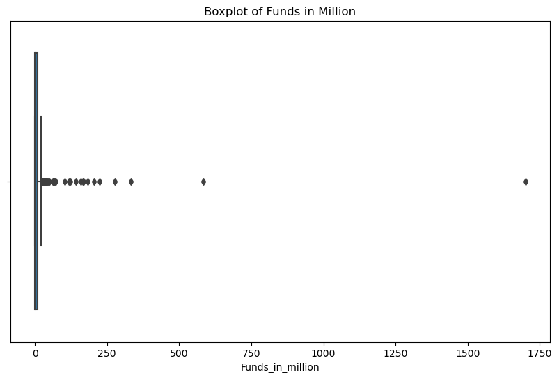

```
Number of Outliers: 60

Frequency of OperatingState:
 Operating    319
Acquired      66
Closed        57
Ipo            4
Name: OperatingState, dtype: int64

T-test results:
T-statistic: 2.6727214329249227
P-value: 0.007898898722704632

Frequency Distribution of Result:
 Contestant         312
Finalist            65
Audience choice     25
Winner              25
Runner up           19
Name: Result, dtype: int64

Percentage of Winners Still Operating: 72.0
Percentage of Contestants Still Operating: 68.58974358974359
Selected Disrupt Events from 2013 onwards:
 Series([], Name: Event, dtype: object)
```

```python
import pandas as pd
import matplotlib.pyplot as plt
import seaborn as sns
from scipy.stats import ttest_ind

# Q1 - Read the CSV file
file_path = '/Users/snbaskarraj/Documents/UT/AppliedStatistics/DS+-+Part3+-+CompanyX_EU.csv'
df = pd.read_csv(file_path)

# Q2 - Data Exploration
# A. Check datatypes
print("Data Types:\n", df.dtypes)

# B. Check for null values
print("\nNull Values:\n", df.isnull().sum())

# Q3 - Data preprocessing & visualization
# A. Drop null values
df.dropna(inplace=True)

# B. Convert 'Funding' to numerical value
df['Funds_in_million'] = df['Funding'].apply(lambda x: float(x[1:-1])/1000 if x[-1] == 'K'
                                             else (float(x[1:-1])*1000 if x[-1] == 'B' else float(x[1:-1])))

# C. Plot boxplot for funds in million
plt.figure(figsize=(10, 6))
sns.boxplot(data=df, x='Funds_in_million')
plt.title('Boxplot of Funds in Million')
plt.show()

# D. Number of outliers greater than the upper fence
Q1 = df['Funds_in_million'].quantile(0.25)
Q3 = df['Funds_in_million'].quantile(0.75)
IQR = Q3 - Q1
upper_fence = Q3 + 1.5 * IQR
outliers = df[df['Funds_in_million'] > upper_fence]
print("Number of Outliers:", outliers.shape[0])

# E. Frequency of OperatingState feature classes
print("\nFrequency of OperatingState:\n", df['OperatingState'].value_counts())

# Q4 - Statistical Analysis
# A, B & C - Significance test
operating = df[df['OperatingState'] == 'Operating']['Funds_in_million']
closed = df[df['OperatingState'] == 'Closed']['Funds_in_million']

# Null hypothesis: There is no significant difference in funds raised between operating and closed companies.
# Alternative hypothesis: There is a significant difference in funds raised between operating and closed companies.
t_stat, p_value = ttest_ind(operating, closed, equal_var=False)
print("\nT-test results:\nT-statistic:", t_stat, "\nP-value:", p_value)

# D - Make a copy of the original data frame
df_copy = df.copy()

# E - Frequency distribution of Result variables
print("\nFrequency Distribution of Result:\n", df_copy['Result'].value_counts())

# F - Calculate percentage of winners and contestants that are still operating
winners_operating = df_copy[(df_copy['Result'] == 'Winner') & (df_copy['OperatingState'] == 'Operating')].shape[0]
total_winners = df_copy[df_copy['Result'] == 'Winner'].shape[0]
winners_operating_percent = (winners_operating / total_winners) * 100

contestants_operating = df_copy[(df_copy['Result'] == 'Contestant') & (df_copy['OperatingState'] == 'Operating')].shape[0]
total_contestants = df_copy[df_copy['Result'] == 'Contestant'].shape[0]
contestants_operating_percent = (contestants_operating / total_contestants) * 100

print("\nPercentage of Winners Still Operating:", winners_operating_percent)
print("Percentage of Contestants Still Operating:", contestants_operating_percent)

# G, H - Hypothesis testing between winners and contestants
# Null hypothesis: There is no difference in proportions of operating companies between winners and contestants.
# Alternative hypothesis: There is a difference in proportions of operating companies between winners and contestants.
# This will be a proportion z-test, which is not directly available in scipy, thus manually calculated or use statsmodels

# I - Select events with 'disrupt' keyword from 2013 onwards
df_disrupt = df_copy[df_copy['Event'].str.contains('disrupt') &
                     (df_copy['Event'].str.contains('2013') |
                      df_copy['Event'].str.contains('2014') |
                      df_copy['Event'].str.contains('2015') |
                      df_copy['Event'].str.contains('2016') |
                      df_copy['Event'].str.contains('2017') |
                      df_copy['Event'].str.contains('2018') |
                      df_copy['Event'].str.contains('2019') |
                      df_copy['Event'].str.contains('2020') |
                      df_copy['Event'].str.contains('2021') |
                      df_copy['Event'].str.contains('2022'))]

print("Selected Disrupt Events from 2013 onwards:\n", df_disrupt['Event'])
```